# Predicting Alpha: Exploratory Analysis

Maarten van der Velde

Last updated: 2020-05-20

# Overview

This notebook contains additional exploratory analyses.

# Setup

```r
library(dplyr)
library(data.table)
library(ggplot2)
library(brms)
library(future)
library(fst)
library(tidyr)
library(readr)
library(stringr)
library(extrafont)
library(wesanderson)
library(tikzDevice)
library(lme4)
library(future)

plan(multiprocess)
```

```r
# font_import() # Run once to populate the R font database with the fonts on the system
loadfonts(quiet = TRUE)

theme_poster <- theme_light(base_size = 14) +
            theme(text = element_text(family = 'Merriweather Sans'),
                  strip.text = element_text(colour = "black"))

theme_paper <- theme_bw() +
  theme(axis.text = element_text(colour = "black"))

condition_colours <- wes_palette("Darjeeling1", n = 5)
condition_colours <- condition_colours[c(1,3)]

knitr::opts_chunk$set(fig.width=16, fig.height=16)

set.seed(0)
```

# Model comparison

Using the preregistered model as a reference model, we can also evaluate simpler and more complex models.

Refit the preregistered model:

```r
s2_test1 <- read_fst(file.path("..", "data", "processed", "s2", "s2_test1.fst"))
s2_test2 <- read_fst(file.path("..", "data", "processed", "s2", "s2_test2.fst"))
test_full <- bind_rows(s2_test1, s2_test2) %>%
  mutate(block = as.factor(block))
```

```
Unequal factor levels: coercing to characterbinding character and factor vector, coercing into character vectorbinding character and factor vector, coercing into character vector
```

```r
test_studied_full <- filter(test_full, studied)

# Filter out excluded participant:
s2_exclude <- read_fst(file.path("..", "data", "processed", "s2", "s2_exclude.fst"))
test <- anti_join(test_full, s2_exclude, by = "subject") %>% droplevels()
```

```
Column `subject` joining factor and character vector, coercing into character vector
```

```r
test_studied <- anti_join(test_studied_full, s2_exclude, by = "subject") %>% droplevels()
```

```
Column `subject` joining factor and character vector, coercing into character vector
```

```r
contrasts(test_studied$condition) <- c(-0.5, 0.5)
contrasts(test_studied$block) <- c(-0.5, 0.5)
```

```r
prior_m1 <- set_prior("cauchy(0, 1)", class = "b")

m1 <- brm(
  correct ~ condition + block + (1 | subject) + (1 | fact_id),
  family = bernoulli,
  data = test_studied,
  prior = prior_m1,
  chains = 4,
  iter = 10000,
  save_all_pars = TRUE,
  sample_prior = TRUE,
  future = TRUE,
  seed = 0,
  file = "model_fits/m1"
)
```

## Simpler models

A model that removes the effect of condition:

```r
m1_nocond <- brm(
  correct ~ block + (1 | subject) + (1 | fact_id),
  family = bernoulli,
  data = test_studied,
  prior = prior_m1,
  chains = 4,
  iter = 10000,
  save_all_pars = TRUE,
  sample_prior = TRUE,
  future = TRUE,
  seed = 0,
  file = "model_fits/m1_nocond"
)

bf_nocond <- bayes_factor(m1, m1_nocond)$bf
```

```
Iteration: 1
Iteration: 2
Iteration: 3
Iteration: 4
Iteration: 5
Iteration: 6
Iteration: 1
Iteration: 2
Iteration: 3
Iteration: 4
Iteration: 5
Iteration: 6
```

A model that removes the effect of block:

```r
m1_noblock <- brm(
  correct ~ condition + (1 | subject) + (1 | fact_id),
  family = bernoulli,
  data = test_studied,
  prior = prior_m1,
  chains = 4,
  iter = 10000,
  save_all_pars = TRUE,
  sample_prior = TRUE,
  future = TRUE,
  seed = 0,
  file = "model_fits/m1_noblock"
)

bf_noblock <- bayes_factor(m1, m1_noblock)$bf
```

```
Iteration: 1
Iteration: 2
Iteration: 3
Iteration: 4
Iteration: 5
Iteration: 6
Iteration: 7
Iteration: 1
Iteration: 2
Iteration: 3
Iteration: 4
Iteration: 5
Iteration: 6
```

An intercept-only model:

```r
m1_intercept <- brm(
  correct ~ 1 + (1 | subject) + (1 | fact_id),
  family = bernoulli,
  data = test_studied,
  # prior = prior_m1,
  chains = 4,
  iter = 10000,
  save_all_pars = TRUE,
  sample_prior = TRUE,
  future = TRUE,
  seed = 0,
  file = "model_fits/m1_intercept"
)

bf_intercept <- bayes_factor(m1, m1_intercept)$bf
```

```
Iteration: 1
Iteration: 2
Iteration: 3
Iteration: 4
Iteration: 5
Iteration: 1
Iteration: 2
Iteration: 3
Iteration: 4
Iteration: 5
Iteration: 6
```

A model without random subject intercepts:

```r
m1_nosubj <- brm(
  correct ~ condition + block + (1 | fact_id),
  family = bernoulli,
  data = test_studied,
  prior = prior_m1,
  chains = 4,
  iter = 10000,
  save_all_pars = TRUE,
  sample_prior = TRUE,
  future = TRUE,
  seed = 0,
  file = "model_fits/m1_nosubj"
)

bf_nosubj <- bayes_factor(m1, m1_nosubj)$bf
```

```
Iteration: 1
Iteration: 2
Iteration: 3
Iteration: 4
Iteration: 5
Iteration: 6
Iteration: 7
Iteration: 1
Iteration: 2
Iteration: 3
Iteration: 4
Iteration: 5
```

A model without random fact intercepts:

```r
m1_nofact <- brm(
  correct ~ condition + block + (1 | subject),
  family = bernoulli,
  data = test_studied,
  prior = prior_m1,
  chains = 4,
  iter = 10000,
  save_all_pars = TRUE,
  sample_prior = TRUE,
  future = TRUE,
  seed = 0,
  file = "model_fits/m1_nofact"
)

bf_nofact <- bayes_factor(m1, m1_nofact)$bf
```

```
Iteration: 1
Iteration: 2
Iteration: 3
Iteration: 4
Iteration: 5
Iteration: 6
Iteration: 1
Iteration: 2
Iteration: 3
Iteration: 4
Iteration: 5
Iteration: 6
```

Finally, a model without any random effects:

```r
m1_norand <- brm(
  correct ~ condition + block,
  family = bernoulli,
  data = test_studied,
  prior = prior_m1,
  chains = 4,
  iter = 10000,
  save_all_pars = TRUE,
  sample_prior = TRUE,
  future = TRUE,
  seed = 0,
  file = "model_fits/m1_norand"
)

bf_norand <- bayes_factor(m1, m1_norand)$bf
```

```
Iteration: 1
Iteration: 2
Iteration: 3
Iteration: 4
Iteration: 5
Iteration: 1
Iteration: 2
Iteration: 3
Iteration: 4
```

## More complex models

Interaction between condition and block:

```r
m1_X <- brm(
  correct ~ condition * block + (1 | subject) + (1 | fact_id),
  family = bernoulli,
  data = test_studied,
  prior = prior_m1,
  chains = 4,
  iter = 10000,
  save_all_pars = TRUE,
  sample_prior = TRUE,
  future = TRUE,
  seed = 0,
  file = "model_fits/m1_X"
)

bf_X <- bayes_factor(m1, m1_X)$bf
```

```
Iteration: 1
Iteration: 2
Iteration: 3
Iteration: 4
Iteration: 5
Iteration: 6
Iteration: 7
Iteration: 1
Iteration: 2
Iteration: 3
Iteration: 4
Iteration: 5
```

## Bayes factor comparison

```r
model_formula <- function(model) {
  return(as.character(model$formula$formula)[3])
}

model_comp <- tibble(model = c(model_formula(m1),
                 model_formula(m1_nocond),
                 model_formula(m1_noblock),
                 model_formula(m1_intercept),
                 model_formula(m1_nosubj),
                 model_formula(m1_nofact),
                 model_formula(m1_norand),
                 model_formula(m1_X)),
               bf = c(1,
                      bf_nocond,
                      bf_noblock,
                      bf_intercept,
                      bf_nosubj,
                      bf_nofact,
                      bf_norand,
                      bf_X))
```

The plot below shows the relative likelihood of the data under each model, with the preregistered model (shown in bold) taken as the reference level. All Bayes factors are smaller than 1, indicating that, out of these models, the preregistered model is the preferred model. Only the model with an interaction between the fixed effects comes close: the data are 0.4637367 times as likely under that model relative to the best model.

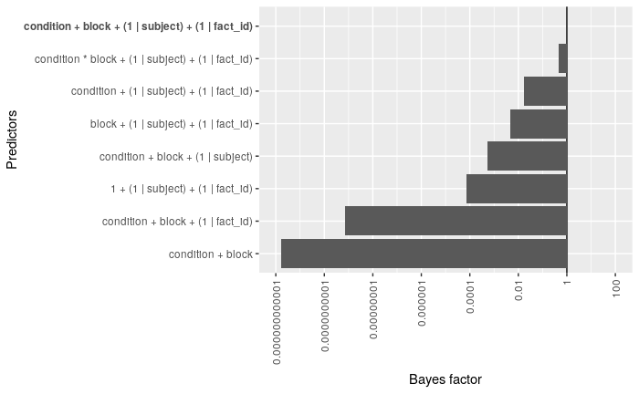

```r
ggplot(model_comp, aes(x = reorder(model, -bf), y = 1/bf)) +
  geom_hline(yintercept = 1) +
  geom_col() +
  scale_y_log10(limits = c(1/1e12, 100), breaks = c(100, 1, 1/100, 1/10000, 1/1000000, 1/100000000, 1/10000000000, 1/1000000000000),
                labels = function(n) {format(n, scientific = FALSE, drop0trailing = TRUE)}) +
  coord_flip() +
  labs(x = "Predictors", y = "Bayes factor") +
  theme(axis.text.x = element_text(angle = 90, vjust = 0.5, hjust = 1),
        axis.text.y = element_text(face = c("plain", "plain", "plain", "plain", "plain", "plain", "plain", "bold")))
```

# Test accuracy as function of difficulty

## Predicted difficulty

We expect response accuracy on the test to be affected by the difficulty of the item, with lower accuracy on items that are predicted to be more difficult.

```r
cities <- read_csv(file.path("..", "stimuli", "setC_with_alpha.csv"), col_types = cols(
  id = col_factor(),
  image = col_character(),
  text = col_logical(),
  answer = col_character()
)) %>%
  select(fact_id = id, answer, alpha = mu)

test_studied_alpha <- left_join(test_studied, cities, by = "fact_id")
```

```r
prior_m_difficulty <- set_prior("cauchy(0, 1)", class = "b")

m_difficulty <- brm(
  correct ~ alpha * condition * block + (1 | subject),
  family = bernoulli,
  data = test_studied_alpha,
  prior = prior_m_difficulty,
  chains = 4,
  iter = 10000,
  save_all_pars = TRUE,
  sample_prior = TRUE,
  future = TRUE,
  seed = 0,
  file = "model_fits/m_difficulty"
)
```

Also fit simpler models for comparison:

```r
m_difficulty_2 <- brm(
  correct ~ alpha + condition * block + (1 | subject),
  family = bernoulli,
  data = test_studied_alpha,
  prior = prior_m_difficulty,
  chains = 4,
  iter = 10000,
  save_all_pars = TRUE,
  sample_prior = TRUE,
  future = TRUE,
  seed = 0,
  file = "model_fits/m_difficulty_2"
)

m_difficulty_3 <- brm(
  correct ~ alpha * condition + block + (1 | subject),
  family = bernoulli,
  data = test_studied_alpha,
  prior = prior_m_difficulty,
  chains = 4,
  iter = 10000,
  save_all_pars = TRUE,
  sample_prior = TRUE,
  future = TRUE,
  seed = 0,
  file = "model_fits/m_difficulty_3"
)

m_difficulty_4 <- brm(
  correct ~ alpha + condition + block + (1 | subject),
  family = bernoulli,
  data = test_studied_alpha,
  prior = prior_m_difficulty,
  chains = 4,
  iter = 10000,
  save_all_pars = TRUE,
  sample_prior = TRUE,
  future = TRUE,
  seed = 0,
  file = "model_fits/m_difficulty_4"
)
```

```r
bayes_factor(m_difficulty, m_difficulty_2)
```

```
Iteration: 1
Iteration: 2
Iteration: 3
Iteration: 4
Iteration: 1
Iteration: 2
Iteration: 3
Iteration: 4
Iteration: 5
Estimated Bayes factor in favor of m_difficulty over m_difficulty_2: 0.83820
```

```r
bayes_factor(m_difficulty, m_difficulty_3)
```

```
Iteration: 1
Iteration: 2
Iteration: 3
Iteration: 4
Iteration: 5
Iteration: 1
Iteration: 2
Iteration: 3
Iteration: 4
Estimated Bayes factor in favor of m_difficulty over m_difficulty_3: 0.30779
```

```r
bayes_factor(m_difficulty, m_difficulty_4)
```

```
Iteration: 1
Iteration: 2
Iteration: 3
Iteration: 4
Iteration: 5
Iteration: 1
Iteration: 2
Iteration: 3
Iteration: 4
Iteration: 5
Iteration: 6
Estimated Bayes factor in favor of m_difficulty over m_difficulty_4: 0.42377
```

The difference between models is not very large, but the best model among the tested alternatives is one with an interaction between predicted rate of forgetting and condition, plus main effects for rate of forgetting, condition, and block, and random intercepts for subjects.

The posteriors of this model are as follows:

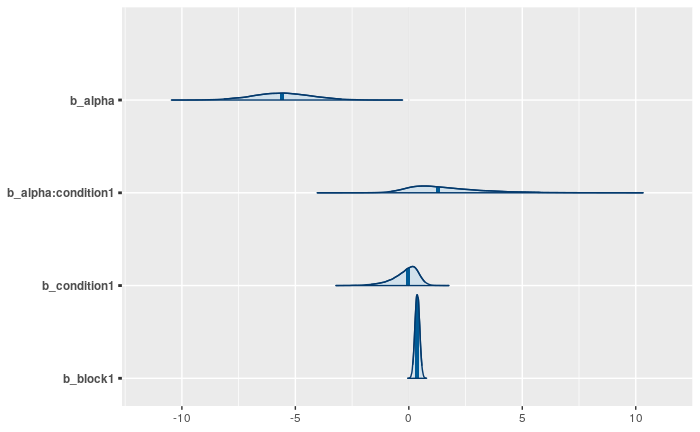

```r
mcmc_plot(m_difficulty_3, pars = c("alpha", "condition", "block"), type = "areas", prob = .95)
```

What if we leave out the condition main effect?

```r
m_difficulty_5 <- brm(
  correct ~ alpha + alpha:condition + block + (1 | subject),
  family = bernoulli,
  data = test_studied_alpha,
  prior = prior_m_difficulty,
  chains = 4,
  iter = 10000,
  save_all_pars = TRUE,
  sample_prior = TRUE,
  future = TRUE,
  seed = 0,
  file = "model_fits/m_difficulty_5"
)

bayes_factor(m_difficulty_3, m_difficulty_5)
```

```
Iteration: 1
Iteration: 2
Iteration: 3
Iteration: 4
Iteration: 5
Iteration: 1
Iteration: 2
Iteration: 3
Iteration: 4
Estimated Bayes factor in favor of m_difficulty_3 over m_difficulty_5: 0.40197
```

Better!

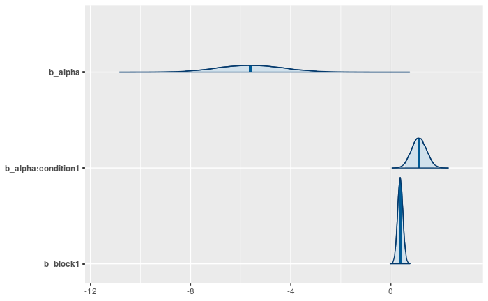

```r
mcmc_plot(m_difficulty_5, pars = c("alpha", "condition", "block"), type = "areas", prob = .95)
```

What if we leave out the main effect of alpha?

```r
m_difficulty_6 <- brm(
  correct ~ alpha:condition + block + (1 | subject),
  family = bernoulli,
  data = test_studied_alpha,
  prior = prior_m_difficulty,
  chains = 4,
  iter = 10000,
  save_all_pars = TRUE,
  sample_prior = TRUE,
  future = TRUE,
  seed = 0,
  file = "model_fits/m_difficulty_6"
)

bayes_factor(m_difficulty_5, m_difficulty_6)
```

```
Iteration: 1
Iteration: 2
Iteration: 3
Iteration: 4
Iteration: 5
Iteration: 1
Iteration: 2
Iteration: 3
Iteration: 4
Iteration: 5
Estimated Bayes factor in favor of m_difficulty_5 over m_difficulty_6: 10.73722
```

Worse.

What if we drop the random subject intercept?

```r
m_difficulty_7 <- brm(
  correct ~ alpha + alpha:condition + block,
  family = bernoulli,
  data = test_studied_alpha,
  prior = prior_m_difficulty,
  chains = 4,
  iter = 10000,
  save_all_pars = TRUE,
  sample_prior = TRUE,
  future = TRUE,
  seed = 0,
  file = "model_fits/m_difficulty_7"
)

bayes_factor(m_difficulty_5, m_difficulty_7)
```

```
Iteration: 1
Iteration: 2
Iteration: 3
Iteration: 4
Iteration: 5
Iteration: 1
Iteration: 2
Iteration: 3
Iteration: 4
Estimated Bayes factor in favor of m_difficulty_5 over m_difficulty_7: 719519371.68757
```

Much worse.

What if we leave out the main effect of block?

```r
m_difficulty_8 <- brm(
  correct ~ alpha + alpha:condition + (1 | subject),
  family = bernoulli,
  data = test_studied_alpha,
  prior = prior_m_difficulty,
  chains = 4,
  iter = 10000,
  save_all_pars = TRUE,
  sample_prior = TRUE,
  future = TRUE,
  seed = 0,
  file = "model_fits/m_difficulty_8"
)

bayes_factor(m_difficulty_5, m_difficulty_8)
```

```
Iteration: 1
Iteration: 2
Iteration: 3
Iteration: 4
Iteration: 1
Iteration: 2
Iteration: 3
Iteration: 4
Iteration: 5
Estimated Bayes factor in favor of m_difficulty_5 over m_difficulty_8: 49.05557
```

Much worse.

The best model fit (`m_difficulty_5`) suggests that test accuracy decreases as predicted rate of forgetting increases (i.e., as the fact gets more difficult), but that this effect is somewhat weaker in the Fact condition, and that test accuracy increases from block 1 to block 2.

```r
lower_alpha <- min(test_studied_alpha$alpha)
upper_alpha <- max(test_studied_alpha$alpha)

m_difficulty_prediction <- crossing(condition = as.factor(c("default", "fact")), block = as.factor(c(1, 2)), alpha = seq(lower_alpha, upper_alpha, by = 0.001))

contrasts(m_difficulty_prediction$condition) <- c(-0.5, 0.5)
contrasts(m_difficulty_prediction$block) <- c(-0.5, 0.5)

pred_acc_test <- data.table(fitted(m_difficulty_5, newdata = m_difficulty_prediction, re_formula = NA))
setnames(pred_acc_test, c("fit", "se", "lower", "upper"))
pred_acc_test <- cbind(m_difficulty_prediction, pred_acc_test) %>%
  mutate(condition = as.factor(str_to_title(condition)))
```

Make the plot shown in the paper:

```r
p <- ggplot(pred_acc_test, aes(x = alpha, y = fit, colour = condition, fill = condition)) +
  facet_grid(~ block, labeller = label_both) +
  geom_ribbon(aes(ymin = lower, ymax = upper), alpha = 0.25, colour = NA) +
  geom_line() +
  scale_colour_manual(NULL, values = condition_colours) +
  scale_fill_manual(NULL, values = condition_colours) +
  scale_y_continuous(limits = c(.5, 1), labels = scales::percent_format(suffix = "\\%")) +
  labs(x = "Predicted fact-level rate of forgetting",  y = "Test accuracy") +
  theme_paper

tikz(file = "../output/test-accuracy-rof.tex", width = 4.75, height = 2)
p
dev.off()
```

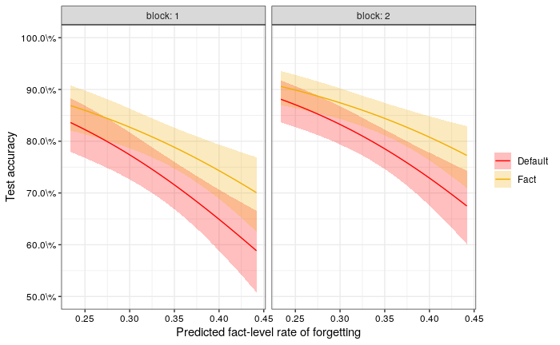

```r
p
```

Make a simplified version that does not include block for presentation:

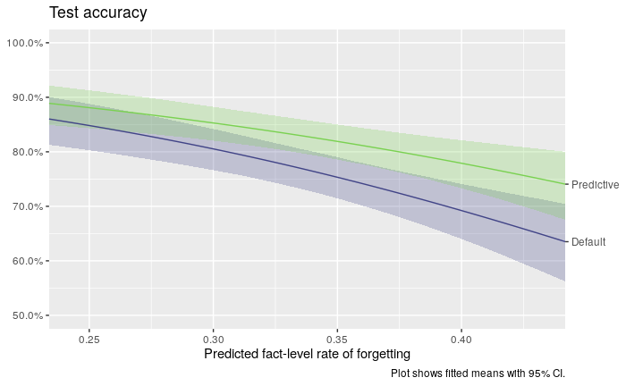

```r
lower_alpha <- min(test_studied_alpha$alpha)
upper_alpha <- max(test_studied_alpha$alpha)

m_difficulty_prediction <- crossing(condition = as.factor(c("default", "fact")), alpha = seq(lower_alpha, upper_alpha, by = 0.001))

contrasts(m_difficulty_prediction$condition) <- c(-0.5, 0.5)

pred_acc_test_simple <- data.table(fitted(m_difficulty_8, newdata = m_difficulty_prediction, re_formula = NA))
setnames(pred_acc_test_simple, c("fit", "se", "lower", "upper"))
pred_acc_test_simple <- cbind(m_difficulty_prediction, pred_acc_test_simple)
pred_acc_test_simple[, condition := str_to_title(condition)]

m_difficulty_prediction <- pred_acc_test_simple %>%
  mutate(condition_alt = ifelse(condition == "Default", "Default", "Predictive"))

m_difficulty_prediction_ends <- filter(m_difficulty_prediction, alpha == max(alpha))

ggplot(m_difficulty_prediction, aes(x = alpha, y = fit, colour = condition_alt, fill = condition_alt)) +
  geom_ribbon(aes(ymin = lower, ymax = upper), alpha = 0.25, colour = NA) +
  geom_line() +
  scale_y_continuous(limits = c(0.5,1), labels = scales::percent_format(), sec.axis = sec_axis(~ ., breaks = m_difficulty_prediction_ends$fit, labels = m_difficulty_prediction_ends$condition_alt)) +
  scale_x_continuous(expand = c(0, 0)) +
  scale_color_viridis_d(begin = 0.2, end = 0.8) +
  scale_fill_viridis_d(begin = 0.2, end = 0.8) +
  guides(colour = FALSE, fill = FALSE) +
  labs(x = "Predicted fact-level rate of forgetting",  y = NULL, title = "Test accuracy", caption = "Plot shows fitted means with 95% CI.")

ggsave(file.path("..", "output", "test_acc_diff.pdf"), device = "pdf", width = 4, height = 3)
```

## Observed difficulty

Instead of basing the model’s prediction of test accuracy on the predicted difficulty of an item, we can also use the observed difficulty: the rate of forgetting that was estimated for the item during the learning session.

Note that this leaves us with a bit less data: only facts that were rehearsed at least 3 times yield a useable rate of forgetting estimate.

```r
observed_alpha_1 <- read_fst(file.path("..", "data", "processed", "s2", "s2_rl1_final_alpha.fst"))
observed_alpha_2 <- read_fst(file.path("..", "data", "processed", "s2", "s2_rl2_final_alpha.fst"))
observed_alpha <- bind_rows(observed_alpha_1, observed_alpha_2) %>%
  anti_join(s2_exclude, by = "subject") %>%
  droplevels()
```

```
Column `subject` joining factor and character vector, coercing into character vector
```

```r
test_studied_alpha_obs <- left_join(test_studied_alpha, observed_alpha, by = c("subject", "fact_id")) %>%
  filter(reps >= 3)
```

Fit the maximal model, but using observed alpha instead of predicted alpha:

```r
m_difficulty_obs <- brm(
  correct ~ final_alpha * condition * block + (1 | subject),
  family = bernoulli,
  data = test_studied_alpha_obs,
  prior = prior_m1,
  chains = 4,
  iter = 10000,
  save_all_pars = TRUE,
  sample_prior = TRUE,
  future = TRUE,
  seed = 0,
  file = "model_fits/m_difficulty_obs"
)
```

Compare to simpler models:

```r
m_difficulty_obs_2 <- brm(
  correct ~ final_alpha + condition * block + (1 | subject),
  family = bernoulli,
  data = test_studied_alpha_obs,
  prior = prior_m1,
  chains = 4,
  iter = 10000,
  save_all_pars = TRUE,
  sample_prior = TRUE,
  future = TRUE,
  seed = 0,
  file = "model_fits/m_difficulty_obs_2"
)

m_difficulty_obs_3 <- brm(
  correct ~ final_alpha * condition + block + (1 | subject),
  family = bernoulli,
  data = test_studied_alpha_obs,
  prior = prior_m1,
  chains = 4,
  iter = 10000,
  save_all_pars = TRUE,
  sample_prior = TRUE,
  future = TRUE,
  seed = 0,
  file = "model_fits/m_difficulty_obs_3"
)

m_difficulty_obs_4 <- brm(
  correct ~ final_alpha + condition + block + (1 | subject),
  family = bernoulli,
  data = test_studied_alpha_obs,
  prior = prior_m1,
  chains = 4,
  iter = 10000,
  save_all_pars = TRUE,
  sample_prior = TRUE,
  future = TRUE,
  seed = 0,
  file = "model_fits/m_difficulty_obs_4"
)

m_difficulty_obs_5 <- brm(
  correct ~ condition + block + (1 | subject),
  family = bernoulli,
  data = test_studied_alpha_obs,
  prior = prior_m1,
  chains = 4,
  iter = 10000,
  save_all_pars = TRUE,
  sample_prior = TRUE,
  future = TRUE,
  seed = 0,
  file = "model_fits/m_difficulty_obs_5"
)
```

```r
bayes_factor(m_difficulty_obs, m_difficulty_obs_2)
```

```
Iteration: 1
Iteration: 2
Iteration: 3
Iteration: 4
Iteration: 5
Iteration: 6
Iteration: 1
Iteration: 2
Iteration: 3
Iteration: 4
Iteration: 5
Iteration: 6
Estimated Bayes factor in favor of m_difficulty_obs over m_difficulty_obs_2: 0.28498
```

```r
bayes_factor(m_difficulty_obs, m_difficulty_obs_3)
```

```
Iteration: 1
Iteration: 2
Iteration: 3
Iteration: 4
Iteration: 5
Iteration: 6
Iteration: 1
Iteration: 2
Iteration: 3
Iteration: 4
Estimated Bayes factor in favor of m_difficulty_obs over m_difficulty_obs_3: 0.25452
```

```r
bayes_factor(m_difficulty_obs, m_difficulty_obs_4)
```

```
Iteration: 1
Iteration: 2
Iteration: 3
Iteration: 4
Iteration: 5
Iteration: 1
Iteration: 2
Iteration: 3
Iteration: 4
Estimated Bayes factor in favor of m_difficulty_obs over m_difficulty_obs_4: 0.14457
```

```r
bayes_factor(m_difficulty_obs, m_difficulty_obs_5)
```

```
Iteration: 1
Iteration: 2
Iteration: 3
Iteration: 4
Iteration: 5
Iteration: 1
Iteration: 2
Iteration: 3
Iteration: 4
Iteration: 5
Estimated Bayes factor in favor of m_difficulty_obs over m_difficulty_obs_5: 0.13658
```

Among these alternatives, the model without interactions or even any effect of predicted rate of forgetting is preferred.

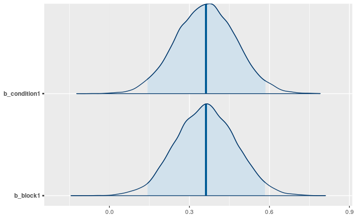

```r
mcmc_plot(m_difficulty_obs_5, pars = c("alpha", "condition", "block"), type = "areas", prob = .95)
```

This means that the model predictions are horizontal lines, with a slight improvement from block 1 to block 2 and in the Fact condition over the Default condition:

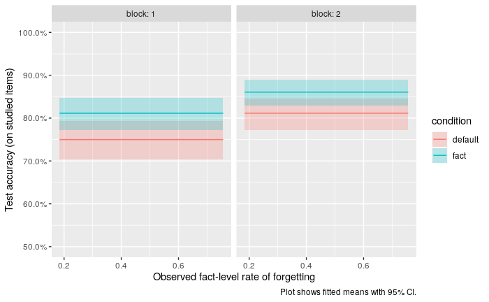

```r
lower_alpha <- min(test_studied_alpha_obs$final_alpha)
upper_alpha <- max(test_studied_alpha_obs$final_alpha)

m_difficulty_obs_prediction <- crossing(condition = as.factor(c("default", "fact")), block = as.factor(c(1, 2)), final_alpha = seq(lower_alpha, upper_alpha, by = 0.001))

contrasts(m_difficulty_obs_prediction$condition) <- c(-0.5, 0.5)
contrasts(m_difficulty_obs_prediction$block) <- c(-0.5, 0.5)

pred_acc_test_obs <- as.data.frame(fitted(m_difficulty_obs_5, newdata = m_difficulty_obs_prediction, re_formula = NA))

m_difficulty_obs_prediction <- bind_cols(m_difficulty_obs_prediction, pred_acc_test_obs)

ggplot(m_difficulty_obs_prediction, aes(x = final_alpha, y = Estimate, colour = condition, fill = condition)) +
  facet_grid(~ block, labeller = label_both) +
  geom_ribbon(aes(ymin = Q2.5, ymax = Q97.5), alpha = 0.25, colour = NA) +
  geom_line() +
  scale_y_continuous(limits = c(0.5, 1), labels = scales::percent_format()) +
  labs(x = "Observed fact-level rate of forgetting",  y = "Test accuracy (on studied items)", caption = "Plot shows fitted means with 95% CI.")
```

Make a simplified plot (without block) for the presentation.

```r
m_difficulty_obs_6 <- brm(
  correct ~ condition + (1 | subject),
  family = bernoulli,
  data = test_studied_alpha_obs,
  prior = prior_m1,
  chains = 4,
  iter = 10000,
  save_all_pars = TRUE,
  sample_prior = TRUE,
  future = TRUE,
  seed = 0,
  file = "model_fits/m_difficulty_obs_6"
)
```

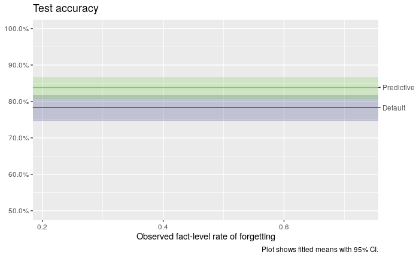

```r
lower_alpha <- min(test_studied_alpha_obs$final_alpha)
upper_alpha <- max(test_studied_alpha_obs$final_alpha)

m_difficulty_obs_prediction <- crossing(condition = as.factor(c("default", "fact")), final_alpha = seq(lower_alpha, upper_alpha, by = 0.001))

contrasts(m_difficulty_obs_prediction$condition) <- c(-0.5, 0.5)

pred_acc_test_obs_simple <- as.data.frame(fitted(m_difficulty_obs_6, newdata = m_difficulty_obs_prediction, re_formula = NA))

m_difficulty_obs_prediction <- bind_cols(m_difficulty_obs_prediction, pred_acc_test_obs_simple) %>%
  mutate(condition_alt = ifelse(condition == "default", "Default", "Predictive"))

m_difficulty_prediction_obs_ends <- filter(m_difficulty_obs_prediction, final_alpha == max(final_alpha))


ggplot(m_difficulty_obs_prediction, aes(x = final_alpha, y = Estimate, colour = condition, fill = condition)) +
  geom_ribbon(aes(ymin = Q2.5, ymax = Q97.5), alpha = 0.25, colour = NA) +
  geom_line() +
  scale_y_continuous(limits = c(0.5,1), labels = scales::percent_format(), sec.axis = sec_axis(~ ., breaks = m_difficulty_prediction_obs_ends$Estimate, labels = m_difficulty_prediction_obs_ends$condition_alt)) +
  scale_x_continuous(expand = c(0, 0)) +
  scale_color_viridis_d(begin = 0.2, end = 0.8) +
  scale_fill_viridis_d(begin = 0.2, end = 0.8) +
  guides(colour = FALSE, fill = FALSE) +
  labs(x = "Observed fact-level rate of forgetting",  y = NULL, title = "Test accuracy", caption = "Plot shows fitted means with 95% CI.")

ggsave(file.path("..", "output", "test_acc_diff_obs.pdf"), device = "pdf", width = 4, height = 3)
```

# Learning accuracy as function of difficulty

## Predicted difficulty

Like on the test, we expect response accuracy during the learning session to be affected by the difficulty of the item, with lower accuracy on items that are predicted to be more difficult. Given that in the Fact condition the system is aware of item difficulty from the start, this effect should be smaller there than in the Default condition.

```r
s2_rl1 <- read_fst(file.path("..", "data", "processed", "s2", "s2_rl1.fst"))
s2_rl2 <- read_fst(file.path("..", "data", "processed", "s2", "s2_rl2.fst"))
s2_rl <- bind_rows(s2_rl1, s2_rl2) %>%
  mutate(block = as.factor(block),
         condition = as.factor(str_to_title(condition)))
```

```
Unequal factor levels: coercing to characterbinding character and factor vector, coercing into character vectorbinding character and factor vector, coercing into character vector
```

```r
# Filter out excluded participant:
s2_exclude <- read_fst(file.path("..", "data", "processed", "s2", "s2_exclude.fst"))
s2_rl <- anti_join(s2_rl, s2_exclude, by = "subject") %>% droplevels()
```

```
Column `subject` joining factor and character vector, coercing into character vector
```

```r
# Add predicted rate of forgetting
s2_rl_alpha <- left_join(s2_rl, cities, by = c("fact_id", "answer"))
```

```r
prior_m_difficulty_learn <- set_prior("cauchy(0, 1)", class = "b")

m_difficulty_learn <- brm(
  correct ~ alpha * condition * block + (1 | subject),
  family = bernoulli,
  data = s2_rl_alpha,
  prior = prior_m_difficulty_learn,
  chains = 4,
  iter = 10000,
  save_all_pars = TRUE,
  sample_prior = TRUE,
  future = TRUE,
  seed = 0,
  file = "model_fits/m_difficulty_learn"
)
```

Also fit simpler models for comparison:

```r
m_difficulty_learn_2 <- brm(
  correct ~ alpha + condition * block + (1 | subject),
  family = bernoulli,
  data = s2_rl_alpha,
  prior = prior_m_difficulty_learn,
  chains = 4,
  iter = 10000,
  save_all_pars = TRUE,
  sample_prior = TRUE,
  future = TRUE,
  seed = 0,
  file = "model_fits/m_difficulty_learn_2"
)

m_difficulty_learn_3 <- brm(
  correct ~ alpha * condition + block + (1 | subject),
  family = bernoulli,
  data = s2_rl_alpha,
  prior = prior_m_difficulty_learn,
  chains = 4,
  iter = 10000,
  save_all_pars = TRUE,
  sample_prior = TRUE,
  future = TRUE,
  seed = 0,
  file = "model_fits/m_difficulty_learn_3"
)

m_difficulty_learn_4 <- brm(
  correct ~ alpha + condition + block + (1 | subject),
  family = bernoulli,
  data = s2_rl_alpha,
  prior = prior_m_difficulty_learn,
  chains = 4,
  iter = 10000,
  save_all_pars = TRUE,
  sample_prior = TRUE,
  future = TRUE,
  seed = 0,
  file = "model_fits/m_difficulty_learn_4"
)
```

```r
bayes_factor(m_difficulty_learn, m_difficulty_learn_2)
```

```
Iteration: 1
Iteration: 2
Iteration: 3
Iteration: 4
Iteration: 5
Iteration: 1
Iteration: 2
Iteration: 3
Iteration: 4
Iteration: 5
Estimated Bayes factor in favor of m_difficulty_learn over m_difficulty_learn_2: 15.27102
```

```r
bayes_factor(m_difficulty_learn, m_difficulty_learn_3)
```

```
Iteration: 1
Iteration: 2
Iteration: 3
Iteration: 4
Iteration: 5
Iteration: 1
Iteration: 2
Iteration: 3
Iteration: 4
Iteration: 5
Estimated Bayes factor in favor of m_difficulty_learn over m_difficulty_learn_3: 0.22368
```

```r
bayes_factor(m_difficulty_learn, m_difficulty_learn_4)
```

```
Iteration: 1
Iteration: 2
Iteration: 3
Iteration: 4
Iteration: 5
Iteration: 1
Iteration: 2
Iteration: 3
Iteration: 4
Iteration: 5
Estimated Bayes factor in favor of m_difficulty_learn over m_difficulty_learn_4: 3.73890
```

The best model among the tested alternatives is one with an interaction between predicted rate of forgetting and condition, plus main effects for rate of forgetting, condition, and block, and random intercepts for subjects.

The posteriors of this model are as follows:

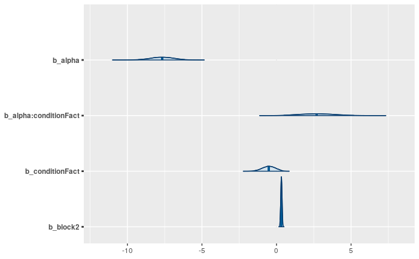

```r
mcmc_plot(m_difficulty_learn_3, pars = c("alpha", "condition", "block"), type = "areas", prob = .95)
```

What if we leave out the condition main effect?

```r
m_difficulty_learn_5 <- brm(
  correct ~ alpha + alpha:condition + block + (1 | subject),
  family = bernoulli,
  data = s2_rl_alpha,
  prior = prior_m_difficulty_learn,
  chains = 4,
  iter = 10000,
  save_all_pars = TRUE,
  sample_prior = TRUE,
  future = TRUE,
  seed = 0,
  file = "model_fits/m_difficulty_learn_5"
)

bayes_factor(m_difficulty_learn_3, m_difficulty_learn_5)
```

```
Iteration: 1
Iteration: 2
Iteration: 3
Iteration: 4
Iteration: 1
Iteration: 2
Iteration: 3
Iteration: 4
Iteration: 5
Estimated Bayes factor in favor of m_difficulty_learn_3 over m_difficulty_learn_5: 0.64903
```

Better!

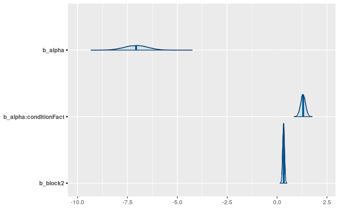

```r
mcmc_plot(m_difficulty_learn_5, pars = c("alpha", "condition", "block"), type = "areas", prob = .95)
```

What if we leave out the main effect of alpha?

```r
m_difficulty_learn_6 <- brm(
  correct ~ alpha:condition + block + (1 | subject),
  family = bernoulli,
  data = s2_rl_alpha,
  prior = prior_m_difficulty_learn,
  chains = 4,
  iter = 10000,
  save_all_pars = TRUE,
  sample_prior = TRUE,
  future = TRUE,
  seed = 0,
  file = "model_fits/m_difficulty_learn_6"
)

bayes_factor(m_difficulty_learn_5, m_difficulty_learn_6)
```

```
Iteration: 1
Iteration: 2
Iteration: 3
Iteration: 4
Iteration: 5
Iteration: 1
Iteration: 2
Iteration: 3
Iteration: 4
Iteration: 5
Estimated Bayes factor in favor of m_difficulty_learn_5 over m_difficulty_learn_6: 12.23710
```

Worse.

What if we drop the random subject intercept?

```r
m_difficulty_learn_7 <- brm(
  correct ~ alpha + alpha:condition + block,
  family = bernoulli,
  data = s2_rl_alpha,
  prior = prior_m_difficulty_learn,
  chains = 4,
  iter = 10000,
  save_all_pars = TRUE,
  sample_prior = TRUE,
  future = TRUE,
  seed = 0,
  file = "model_fits/m_difficulty_learn_7"
)

bayes_factor(m_difficulty_learn_5, m_difficulty_learn_7)
```

```
Iteration: 1
Iteration: 2
Iteration: 3
Iteration: 4
Iteration: 5
Iteration: 6
Iteration: 1
Iteration: 2
Iteration: 3
Iteration: 4
Estimated Bayes factor in favor of m_difficulty_learn_5 over m_difficulty_learn_7: 15806899656833370648265832779367222186313988656498190258783071340606906256088218206208.00000
```

Much worse.

What if we leave out the main effect of block?

```r
m_difficulty_learn_8 <- brm(
  correct ~ alpha + alpha:condition + (1 | subject),
  family = bernoulli,
  data = s2_rl_alpha,
  prior = prior_m_difficulty_learn,
  chains = 4,
  iter = 10000,
  save_all_pars = TRUE,
  sample_prior = TRUE,
  future = TRUE,
  seed = 0,
  file = "model_fits/m_difficulty_learn_8"
)

bayes_factor(m_difficulty_learn_5, m_difficulty_learn_8)
```

```
Iteration: 1
Iteration: 2
Iteration: 3
Iteration: 4
Iteration: 5
Iteration: 1
Iteration: 2
Iteration: 3
Iteration: 4
Estimated Bayes factor in favor of m_difficulty_learn_5 over m_difficulty_learn_8: 8563718707.73753
```

Much worse.

The best model fit (`m_difficulty_learn_5`) has the same predictor structure as the one for test accuracy. It suggests that response accuracy during the learning session decreases as predicted rate of forgetting increases (i.e., as the fact gets more difficult), but that this effect is somewhat weaker in the Fact condition, and that learning accuracy increases from block 1 to block 2.

```r
lower_alpha <- min(s2_rl_alpha$alpha)
upper_alpha <- max(s2_rl_alpha$alpha)

m_difficulty_learn_prediction <- crossing(condition = as.factor(c("Default", "Fact")), block = as.factor(c(1, 2)), alpha = seq(lower_alpha, upper_alpha, by = 0.001))

contrasts(m_difficulty_learn_prediction$condition) <- c(-0.5, 0.5)
contrasts(m_difficulty_learn_prediction$block) <- c(-0.5, 0.5)

pred_acc_learn <- data.table(fitted(m_difficulty_learn_5, newdata = m_difficulty_learn_prediction, re_formula = NA))
setnames(pred_acc_learn, c("fit", "se", "lower", "upper"))
pred_acc_learn <- cbind(m_difficulty_learn_prediction, pred_acc_learn)
```

Make the plot shown in the paper:

```r
p <- ggplot(pred_acc_learn, aes(x = alpha, y = fit, colour = condition, fill = condition)) +
  facet_grid(~ block, labeller = label_both) +
  geom_ribbon(aes(ymin = lower, ymax = upper), alpha = 0.25, colour = NA) +
  geom_line() +
  scale_colour_manual(NULL, values = condition_colours) +
  scale_fill_manual(NULL, values = condition_colours) +
  scale_y_continuous(limits = c(.5, 1), labels = scales::percent_format(suffix = "\\%")) +
  labs(x = "Predicted fact-level rate of forgetting",  y = "Learning accuracy") +
  theme_paper

tikz(file = "../output/learning-accuracy-rof.tex", width = 4.75, height = 2)
p
dev.off()
```

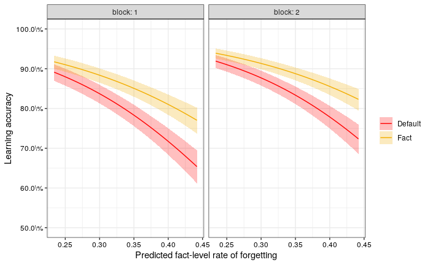

```r
p
```

Also make a simplified, combined plot for in the paper:

```r
lower_alpha <- min(s2_rl_alpha$alpha)
upper_alpha <- max(s2_rl_alpha$alpha)

m_difficulty_learn_prediction <- crossing(condition = as.factor(c("Default", "Fact")), alpha = seq(lower_alpha, upper_alpha, by = 0.001))

contrasts(m_difficulty_learn_prediction$condition) <- c(-0.5, 0.5)

pred_acc_learn_simple <- data.table(fitted(m_difficulty_learn_8, newdata = m_difficulty_learn_prediction, re_formula = NA))
setnames(pred_acc_learn_simple, c("fit", "se", "lower", "upper"))
pred_acc_learn_simple <- cbind(m_difficulty_learn_prediction, pred_acc_learn_simple)
```

```r
pred_acc_learn_simple[, stage := "Learning session"]
pred_acc_test_simple[, stage := "Test"]

pred_acc_combi_simple <- rbind(pred_acc_learn_simple, pred_acc_test_simple)
```

```r
test_acc_avg <- test_studied_alpha %>%
  mutate(condition = as.factor(str_to_title(condition))) %>%
  group_by(condition, fact_id, alpha) %>%
  summarise(accuracy = mean(correct),
            accuracy_se = sd(correct) / sqrt(n())) %>%
  mutate(stage = "Test")

learning_acc_avg <- s2_rl_alpha %>%
  group_by(condition, fact_id, subject) %>%
  summarise(accuracy_subj = mean(correct)) %>%
  group_by(condition, fact_id) %>%
  summarise(accuracy = mean(accuracy_subj),
            accuracy_se = sd(accuracy_subj) / sqrt(n())) %>%
  left_join(cities, by = "fact_id") %>%
  select(-answer) %>%
  mutate(stage = "Learning session")

acc_avg <- bind_rows(test_acc_avg, learning_acc_avg)
```

```r
p <- ggplot(data = pred_acc_combi_simple, aes(x = alpha, y = fit, colour = condition, fill = condition)) +
  facet_grid(~ stage) +
  geom_linerange(data = acc_avg, aes(y = NULL, ymin = accuracy - accuracy_se, ymax = accuracy + accuracy_se), alpha = .15) +
  geom_point(data = acc_avg, aes(y = accuracy), size = .2, alpha = .5) +
  geom_ribbon(aes(ymin = lower, ymax = upper), alpha = 0.25, colour = NA) +
  geom_line() +
  scale_colour_manual(NULL, values = condition_colours) +
  scale_fill_manual(NULL, values = condition_colours) +
  # scale_y_continuous(limits = c(.5, 1), labels = scales::percent_format(suffix = "\\%")) +
  scale_y_continuous(labels = scales::percent_format(suffix = "\\%")) +
  # guides(colour = guide_legend(reverse = TRUE),
  #        fill = guide_legend(reverse = TRUE)) +
  labs(x = "Predicted fact-level rate of forgetting",  y = "Response accuracy") +
  theme_paper

tikz(file = "../output/combi-accuracy-rof.tex", width = 4.75, height = 2)
p
dev.off()
```

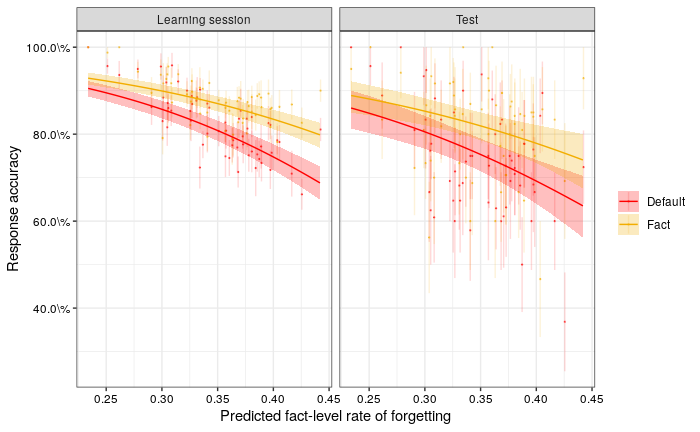

```r
p
```

```r
p <- ggplot(data = pred_acc_combi_simple, aes(x = alpha, y = fit, colour = condition, fill = condition)) +
  facet_grid(~ stage) +
  geom_ribbon(aes(ymin = lower, ymax = upper), alpha = 0.25, colour = NA) +
  geom_line() +
  scale_colour_manual(NULL, values = condition_colours) +
  scale_fill_manual(NULL, values = condition_colours) +
  scale_y_continuous(limits = c(.5, 1), labels = scales::percent_format(suffix = "\\%")) +
  # guides(colour = guide_legend(reverse = TRUE),
  #        fill = guide_legend(reverse = TRUE)) +
  labs(x = "Predicted fact-level rate of forgetting",  y = "Response accuracy") +
  theme_paper

tikz(file = "../output/combi-accuracy-rof-nodata.tex", width = 4.75, height = 2)
p
dev.off()
```

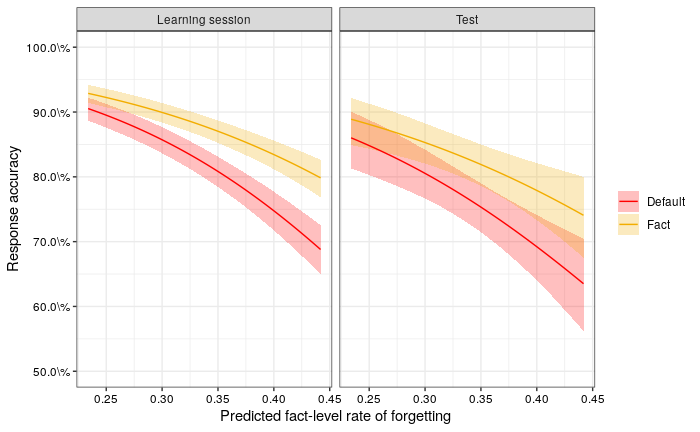

```r
p
```

# Repetitions as a function of difficulty

We expect items that are predicted to be more difficult to also be repeated more during the learning session. This effect should be stronger in the Fact condition, where the algorithm starts out knowing that a fact is difficult and should be repeated often, than in the Default condition, where all facts are initially implicitly assumed to require the same number of repetitions.

```r
presentations <- s2_rl_alpha %>%
  group_by(condition, subject, fact_id, alpha) %>%
  summarise(reps = n())

presentations_mean <- presentations %>%
  group_by(condition, fact_id, alpha) %>%
  summarise(reps_mean = mean(reps),
            reps_se = sd(reps) / sqrt(n()))
```

Mean number of presentations per fact:

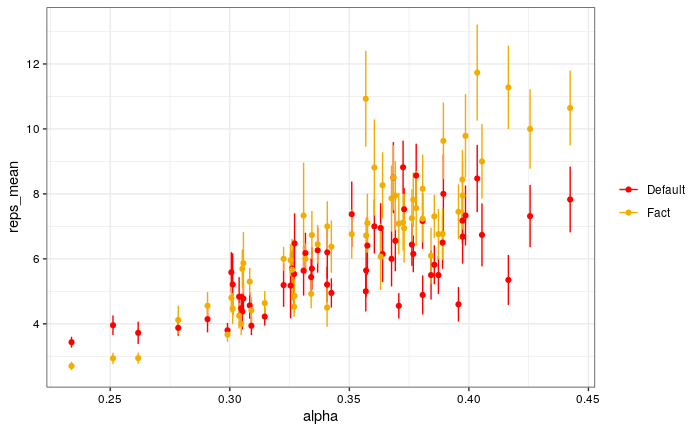

```r
ggplot(presentations_mean, aes(x = alpha, y = reps_mean, colour = condition)) +
  geom_errorbar(aes(ymin = reps_mean - reps_se, ymax = reps_mean + reps_se)) +
  geom_point() +
  scale_colour_manual(NULL, values = condition_colours) +
  theme_paper
```

Fit a regression model to visualise this in a cleaner way. The dependent variable is the number of presentations (a count variable), so a Poisson distribution makes sense.

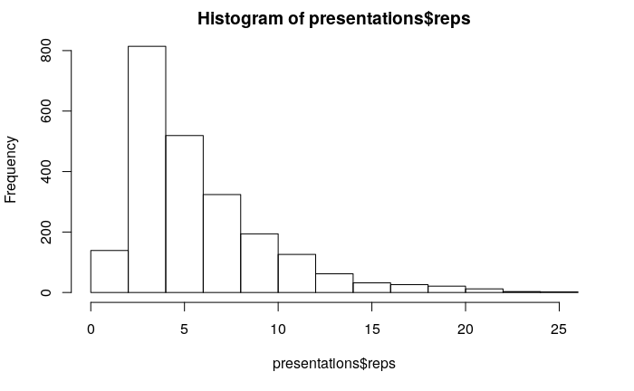

```r
hist(presentations$reps)
```

```r
prior_m_presentations <- set_prior("cauchy(0, 1)", class = "b")

m_presentations <- brm(
  reps ~ alpha * condition + (1 | subject),
  family = poisson,
  data = presentations,
  prior = prior_m_presentations,
  chains = 4,
  iter = 10000,
  save_all_pars = TRUE,
  sample_prior = TRUE,
  future = TRUE,
  seed = 0,
  file = "model_fits/m_presentations"
)
```

```r
m_presentations_2 <- brm(
  reps ~ alpha + condition + (1 | subject),
  family = poisson,
  data = presentations,
  prior = prior_m_presentations,
  chains = 4,
  iter = 10000,
  save_all_pars = TRUE,
  sample_prior = TRUE,
  future = TRUE,
  seed = 0,
  file = "model_fits/m_presentations_2"
)

m_presentations_3 <- brm(
  reps ~ alpha + alpha:condition + (1 | subject),
  family = poisson,
  data = presentations,
  prior = prior_m_presentations,
  chains = 4,
  iter = 10000,
  save_all_pars = TRUE,
  sample_prior = TRUE,
  future = TRUE,
  seed = 0,
  file = "model_fits/m_presentations_3"
)

m_presentations_3 <- brm(
  reps ~ alpha:condition + condition + (1 | subject),
  family = poisson,
  data = presentations,
  prior = prior_m_presentations,
  chains = 4,
  iter = 10000,
  save_all_pars = TRUE,
  sample_prior = TRUE,
  future = TRUE,
  seed = 0,
  file = "model_fits/m_presentations_3"
)

m_presentations_4 <- brm(
  reps ~ alpha + (1 | subject),
  family = poisson,
  data = presentations,
  prior = prior_m_presentations,
  chains = 4,
  iter = 10000,
  save_all_pars = TRUE,
  sample_prior = TRUE,
  future = TRUE,
  seed = 0,
  file = "model_fits/m_presentations_4"
)

m_presentations_5 <- brm(
  reps ~ condition + (1 | subject),
  family = poisson,
  data = presentations,
  prior = prior_m_presentations,
  chains = 4,
  iter = 10000,
  save_all_pars = TRUE,
  sample_prior = TRUE,
  future = TRUE,
  seed = 0,
  file = "model_fits/m_presentations_5"
)
m_presentations_6 <- brm(
  reps ~ 1 + (1 | subject),
  family = poisson,
  data = presentations,
  chains = 4,
  iter = 10000,
  save_all_pars = TRUE,
  sample_prior = TRUE,
  future = TRUE,
  seed = 0,
  file = "model_fits/m_presentations_6"
)
```

The full model is clearly the best:

```r
bayes_factor(m_presentations, m_presentations_2)
```

```
Iteration: 1
Iteration: 2
Iteration: 3
Iteration: 4
Iteration: 5
Iteration: 1
Iteration: 2
Iteration: 3
Iteration: 4
Iteration: 5
Estimated Bayes factor in favor of m_presentations over m_presentations_2: 69761554.31727
```

```r
bayes_factor(m_presentations, m_presentations_3)
```

```
Iteration: 1
Iteration: 2
Iteration: 3
Iteration: 4
Iteration: 5
Iteration: 1
Iteration: 2
Iteration: 3
Iteration: 4
Estimated Bayes factor in favor of m_presentations over m_presentations_3: 127158.17687
```

```r
bayes_factor(m_presentations, m_presentations_4)
```

```
Iteration: 1
Iteration: 2
Iteration: 3
Iteration: 4
Iteration: 1
Iteration: 2
Iteration: 3
Iteration: 4
Iteration: 5
Estimated Bayes factor in favor of m_presentations over m_presentations_4: 251717522872119200.00000
```

```r
bayes_factor(m_presentations, m_presentations_5)
```

```
Iteration: 1
Iteration: 2
Iteration: 3
Iteration: 4
Iteration: 5
Iteration: 1
Iteration: 2
Iteration: 3
Iteration: 4
Iteration: 5
Estimated Bayes factor in favor of m_presentations over m_presentations_5: 1110928788706615102493094592053685183209714316844165485009409532048897451438238322953496424772250493536916372559450737380728423753011111292058815271272448.00000
```

```r
bayes_factor(m_presentations, m_presentations_6)
```

```
Iteration: 1
Iteration: 2
Iteration: 3
Iteration: 4
Iteration: 5
Iteration: 1
Iteration: 2
Iteration: 3
Iteration: 4
Iteration: 5
Estimated Bayes factor in favor of m_presentations over m_presentations_6: 911075860035413349215675997552794709353118697887032872713835306807345409623942871017663515920032714699790475264512847945954765398983865592329300983076665383976960.00000
```

```
No divergences to plot.
```

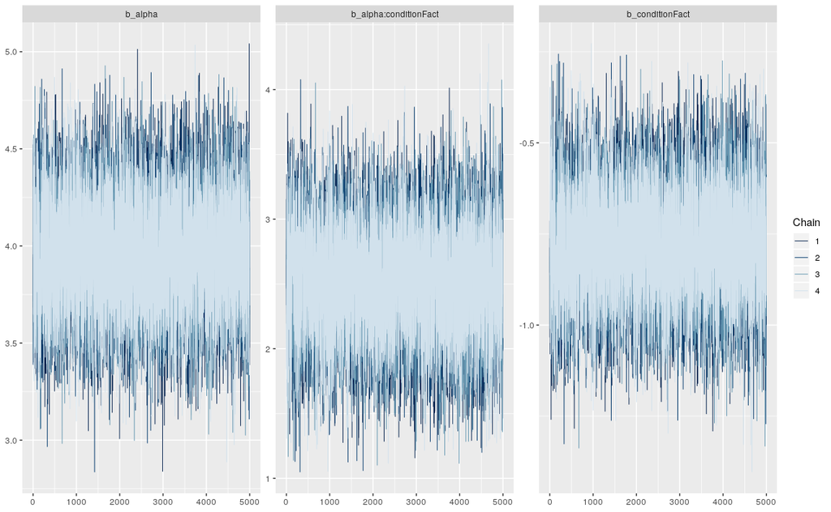

```r
mcmc_plot(m_presentations, pars = c("alpha", "condition"), type = "trace")
```

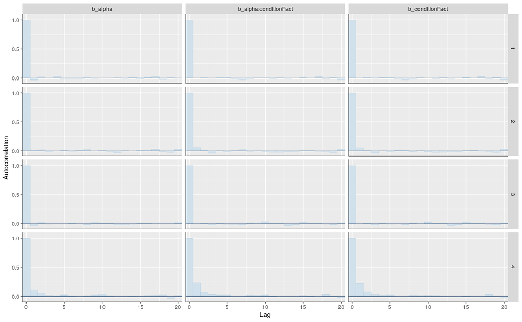

```r
mcmc_plot(m_presentations, pars = c("alpha", "condition"), type = "acf_bar")
```

```r
summary(m_presentations)
```

```
 Family: poisson
  Links: mu = log
Formula: reps ~ alpha * condition + (1 | subject)
   Data: presentations (Number of observations: 2274)
Samples: 4 chains, each with iter = 10000; warmup = 5000; thin = 1;
         total post-warmup samples = 20000

Group-Level Effects:
~subject (Number of levels: 68)
              Estimate Est.Error l-95% CI u-95% CI Rhat Bulk_ESS Tail_ESS
sd(Intercept)     0.16      0.02     0.13     0.19 1.00     6618    11251

Population-Level Effects:
                    Estimate Est.Error l-95% CI u-95% CI Rhat Bulk_ESS Tail_ESS
Intercept               0.39      0.10     0.19     0.59 1.00    16748    17170
alpha                   3.96      0.28     3.41     4.51 1.00    18100    17089
conditionFact          -0.78      0.15    -1.07    -0.49 1.00    16537    16010
alpha:conditionFact     2.52      0.41     1.70     3.32 1.00    16475    15937

Samples were drawn using sampling(NUTS). For each parameter, Bulk_ESS
and Tail_ESS are effective sample size measures, and Rhat is the potential
scale reduction factor on split chains (at convergence, Rhat = 1).
```

Visualise the model’s population-level estimates, along with their 95% credible intervals:

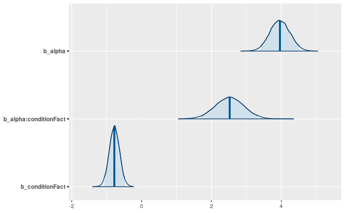

```r
mcmc_plot(m_presentations, pars = c("alpha", "condition"), type = "areas", prob = .95)
```

The model makes the following predictions, based on its fixed effects:

```r
lower_alpha <- min(presentations$alpha)
upper_alpha <- max(presentations$alpha)

m_presentations_prediction <- crossing(condition = as.factor(c("Default", "Fact")), alpha = seq(lower_alpha, upper_alpha, by = 0.001))

pred_acc <- data.table(fitted(m_presentations, newdata = m_presentations_prediction, re_formula = NA))
setnames(pred_acc, c("fit", "se", "lower", "upper"))
pred_acc <- cbind(m_presentations_prediction, pred_acc)
```

Make the plot shown in the paper:

```r
p <- ggplot(pred_acc, aes(x = alpha, y = fit, colour = condition, fill = condition)) +
  geom_errorbar(data = presentations_mean, aes(y = reps_mean, ymin = reps_mean - reps_se, ymax = reps_mean + reps_se), alpha = .15) +
  geom_point(data = presentations_mean, aes(y = reps_mean), alpha = .5) +
  geom_ribbon(aes(ymin = lower, ymax = upper), alpha = 0.25, colour = NA) +
  geom_line() +
  scale_colour_manual(NULL, values = condition_colours) +
  scale_fill_manual(NULL, values = condition_colours) +
  scale_y_continuous(limits = c(2, 13.5), breaks = c(2, 4, 6, 8, 10, 12)) +
  labs(x = "Predicted fact-level rate of forgetting",  y = "Number of presentations") +
  theme_paper
```

```
Ignoring unknown aesthetics: y
```

```r
tikz(file = "../output/presentation-count-rof.tex", width = 4.75, height = 2)
p
dev.off()
```

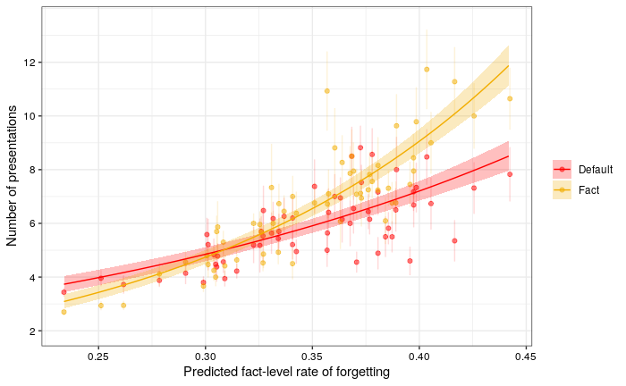

```r
p
```

# Response accuracy during learning

Like we saw in Experiment 1, response accuracy during the learning session was affected by the prediction type.

```r
s2_rl1 <- read_fst(file.path("..", "data", "processed", "s2", "s2_rl1.fst"))
s2_rl2 <- read_fst(file.path("..", "data", "processed", "s2", "s2_rl2.fst"))
s2_rl <- bind_rows(s2_rl1, s2_rl2) %>%
  mutate(block = as.factor(block),
         condition = as.factor(str_to_title(condition)))
```

```
Unequal factor levels: coercing to characterbinding character and factor vector, coercing into character vectorbinding character and factor vector, coercing into character vector
```

```r
# Filter out excluded participant:
s2_exclude <- read_fst(file.path("..", "data", "processed", "s2", "s2_exclude.fst"))
s2_rl <- anti_join(s2_rl, s2_exclude, by = "subject") %>% droplevels()
```

```
Column `subject` joining factor and character vector, coercing into character vector
```

```r
rl_acc <- s2_rl %>%
  group_by(subject, block, condition) %>%
  summarise(p_corr = mean(correct))
```

```r
p <- rl_acc %>%
  ggplot(aes(y = p_corr, x = condition, group = condition)) +
  geom_jitter(width = 0.1, height = 0, alpha = 0.3, aes(colour = condition)) +
  geom_violin(fill = NA, width = 0.75) +
  geom_boxplot(width = 0.2, outlier.shape = NA, fill = NA) +
  guides(colour = FALSE) +
  expand_limits(y = 0) +
  scale_y_continuous(labels = scales::percent_format(suffix = "\\%")) +
  scale_colour_manual(values = condition_colours) +
  labs(x = NULL,
       y = "Response accuracy") +
  theme_paper

tikz(file = "../output/learning-accuracy.tex", width = 4.75/2, height = 2)
p
dev.off()
```

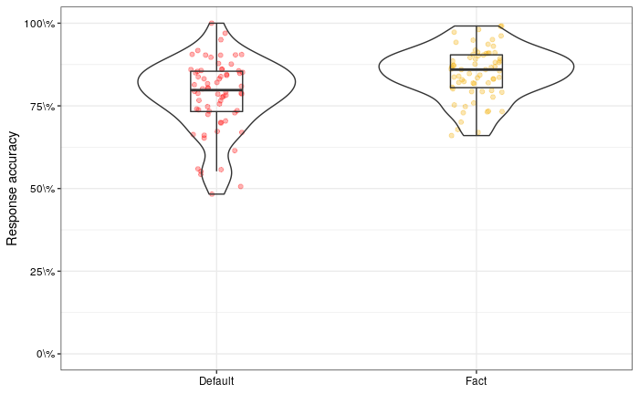

```r
p
```

Fit a Bayesian logistic mixed-effects model:

```r
prior_m3 <- set_prior("cauchy(0, 1)", class = "b")

m3 <- brm(
  correct ~ condition + block + (1 | subject) + (1 | fact_id),
  family = bernoulli,
  data = s2_rl,
  prior = prior_m3,
  chains = 4,
  iter = 10000,
  save_all_pars = TRUE,
  sample_prior = TRUE,
  future = TRUE,
  seed = 0,
  file = "model_fits/m3"
)
```

```
No divergences to plot.
```

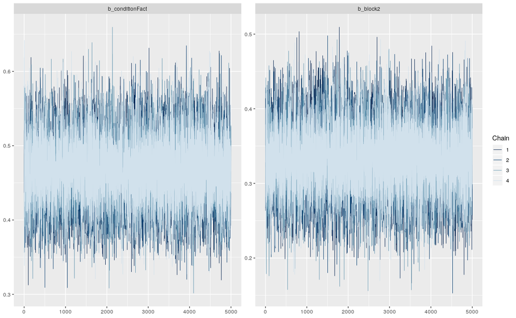

```r
mcmc_plot(m3, pars = c("condition", "block"), type = "trace")
```

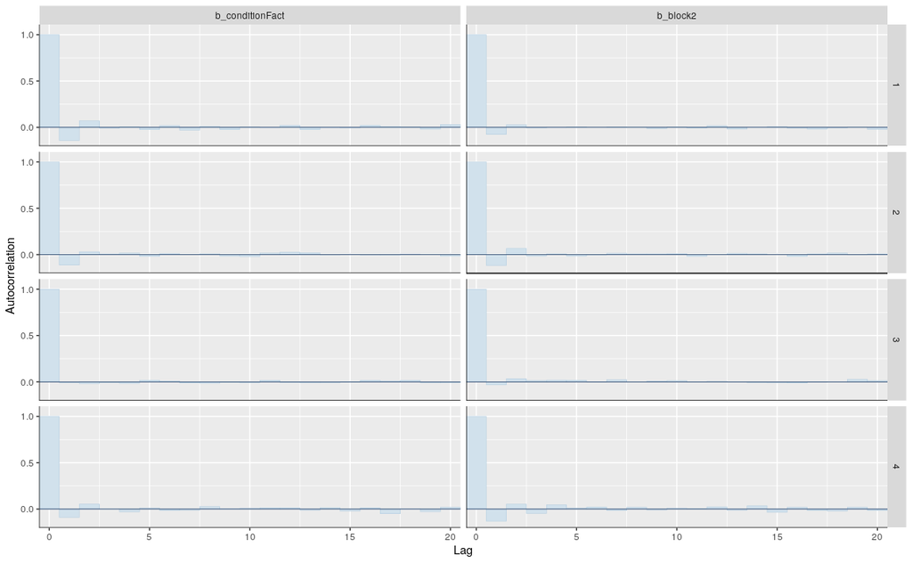

```r
mcmc_plot(m3, pars = c("condition", "block"), type = "acf_bar")
```

```r
summary(m3)
```

```
 Family: bernoulli
  Links: mu = logit
Formula: correct ~ condition + block + (1 | subject) + (1 | fact_id)
   Data: s2_rl (Number of observations: 14193)
Samples: 4 chains, each with iter = 10000; warmup = 5000; thin = 1;
         total post-warmup samples = 20000

Group-Level Effects:
~fact_id (Number of levels: 60)
              Estimate Est.Error l-95% CI u-95% CI Rhat Bulk_ESS Tail_ESS
sd(Intercept)     0.38      0.05     0.29     0.50 1.00     5090     9546

~subject (Number of levels: 68)
              Estimate Est.Error l-95% CI u-95% CI Rhat Bulk_ESS Tail_ESS
sd(Intercept)     0.57      0.06     0.47     0.70 1.00     3622     7395

Population-Level Effects:
              Estimate Est.Error l-95% CI u-95% CI Rhat Bulk_ESS Tail_ESS
Intercept         1.30      0.09     1.12     1.48 1.00     2717     5806
conditionFact     0.47      0.05     0.38     0.56 1.00    22622    15228
block2            0.33      0.05     0.24     0.42 1.00    20784    15253

Samples were drawn using sampling(NUTS). For each parameter, Bulk_ESS
and Tail_ESS are effective sample size measures, and Rhat is the potential
scale reduction factor on split chains (at convergence, Rhat = 1).
```

Visualise the model’s population-level estimates, along with their 95% credible intervals:

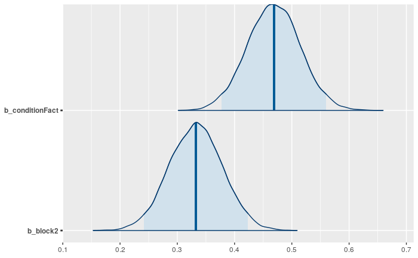

```r
mcmc_plot(m3, pars = c("condition", "block"), type = "areas", prob = .95)
```

The model makes the following predictions, based on its fixed effects.

```r
# Get fitted values
new_data <- crossing(condition = levels(s2_rl$condition), block = levels(s2_rl$block))
fit_m3 <- data.table(fitted(m3,
                            newdata = new_data,
                            re_formula = NA,
                            summary = FALSE))
setnames(fit_m3, as.character(interaction(new_data$condition, new_data$block)))

fit_m3_summary <- data.table(fitted(m3,
                                    newdata = new_data,
                                    re_formula = NA))
setnames(fit_m3_summary, c("fit", "se", "lower", "upper"))
fit_m3_summary <- cbind(new_data, fit_m3_summary)
```

Overall response accuracy (across blocks and conditions):

```r
quantile((fit_m3$Default.1 + fit_m3$Default.2 + fit_m3$Fact.1 + fit_m3$Fact.2)/4,
         probs = c(.5, .025, .975))
```

```
      50%      2.5%     97.5%
0.8416314 0.8174265 0.8636746
```

Difference in response accuracy between Fact condition and Default condition (across blocks):

```r
fact_vs_default <- (fit_m3$Fact.1 + fit_m3$Fact.2)/2 - (fit_m3$Default.1 + fit_m3$Default.2)/2
quantile(fact_vs_default, probs = c(.5, .025, .975))
```

```
       50%       2.5%      97.5%
0.06146087 0.04841447 0.07567907
```

Difference in response accuracy between block 2 and block 1 (across conditions):

```r
block2_vs_block1 <- (fit_m3$Default.2 + fit_m3$Fact.2)/2 - (fit_m3$Default.1 + fit_m3$Fact.1)/2
quantile(block2_vs_block1, probs = c(.5, .025, .975))
```

```
       50%       2.5%      97.5%
0.04363520 0.03115586 0.05725533
```

# Test score

The plot below shows the test scores on all 30 items for each block and condition. It looks like the Fact condition may outperform the Default condition in the first block, but not in the second block. Is this indeed the case?

```r
test_scores <- test %>%
  group_by(subject, block, condition) %>%
  summarise(score = sum(correct)) %>%
    mutate(condition_order = case_when(
    block == 1 && condition == "default" ~ "DefaultFact",
    block == 2 && condition == "fact" ~ "DefaultFact",
    block == 1 && condition == "fact" ~ "FactDefault",
    block == 2 && condition == "default" ~ "FactDefault"
  )) %>%
  ungroup() %>%
  mutate(condition_order = as.factor(condition_order))
```

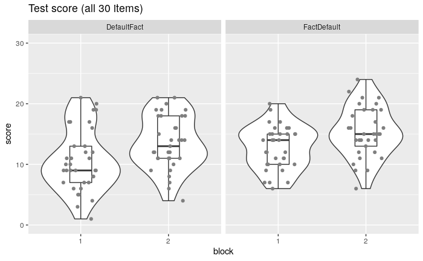

```r
ggplot(test_scores, aes(x = block, y = score)) +
  facet_grid(~ condition_order) +
  geom_violin() +
  geom_boxplot(width = 0.25) +
  geom_jitter(height = 0, width = 0.2, colour = "grey50") +
  scale_y_continuous(limits = c(0, 30)) +
  labs(title = "Test score (all 30 items)")
```

Make the simplified plot shown in the paper:

```r
p <- test_scores %>%
  mutate(condition = str_to_title(condition)) %>%
  ggplot(aes(y = score, x = condition, group = condition)) +
  geom_jitter(width = 0.1, height = 0, alpha = 0.3, aes(colour = condition)) +
  geom_violin(fill = NA, width = 0.75) +
  geom_boxplot(width = 0.2, outlier.shape = NA, fill = NA) +
  guides(colour = FALSE) +
  expand_limits(y = 0) +
  scale_y_continuous(limits = c(0, 30)) +
  scale_colour_manual(values = condition_colours) +
  labs(x = NULL,
       y = "Test score") +
  theme_paper

tikz(file = "../output/test-score.tex", width = 4.75/2, height = 2)
p
dev.off()
```

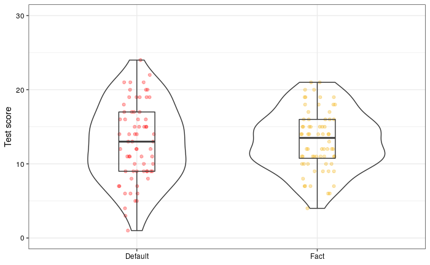

```r
p
```

If using fact-level predictions improves the learning and subsequent test performance, the test score in Fact blocks should be higher than the test score in Default blocks, controlling for block order.

```r
test_scores_diff <- test_scores %>%
  group_by(subject, condition_order) %>%
  summarise(improvement = score[condition == "fact"] - score[condition == "default"])
```

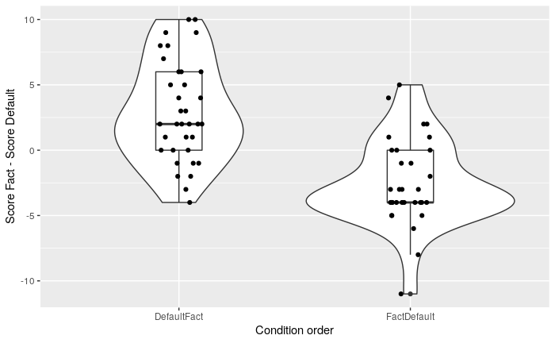

```r
ggplot(test_scores_diff, aes(x = condition_order, y = improvement)) +
  geom_violin() +
  geom_boxplot(width = 0.2) +
  geom_jitter(height = 0, width = 0.1) +
  labs(x = "Condition order", y = "Score Fact - Score Default")
```

The difference in test score is always an integer, but can be smaller than zero. For that reason, I’m modelling the score difference using a shifted Poisson distribution:

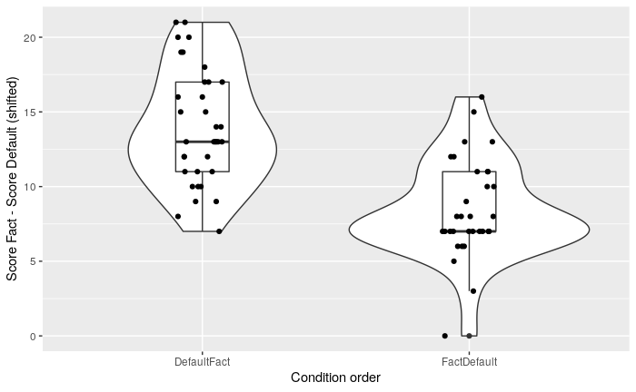

```r
improvement_min <- min(test_scores_diff$improvement)
test_scores_diff$improvement_shifted <- test_scores_diff$improvement - improvement_min

ggplot(test_scores_diff, aes(x = condition_order, y = improvement_shifted)) +
  geom_violin() +
  geom_boxplot(width = 0.2) +
  geom_jitter(height = 0, width = 0.1) +
  labs(x = "Condition order", y = "Score Fact - Score Default (shifted)")
```

```r
contrasts(test_scores_diff$condition_order) <- c(-0.5, 0.5)

m_scores <- brm(improvement_shifted ~ condition_order,
                family = poisson(),
                data = test_scores_diff,
                prior = set_prior("cauchy(0, 1)", class = "b"),
                chains = 4,
                iter = 10000,
                save_all_pars = TRUE,
                sample_prior = TRUE,
                future = TRUE,
                seed = 0,
                file = "model_fits/m_scores"
                )
```

```r
summary(m_scores)
```

```
 Family: poisson
  Links: mu = log
Formula: improvement_shifted ~ condition_order
   Data: test_scores_diff (Number of observations: 68)
Samples: 4 chains, each with iter = 10000; warmup = 5000; thin = 1;
         total post-warmup samples = 20000

Population-Level Effects:
                 Estimate Est.Error l-95% CI u-95% CI Rhat Bulk_ESS Tail_ESS
Intercept            2.38      0.04     2.31     2.46 1.00    15720    13246
condition_order1    -0.50      0.08    -0.65    -0.35 1.00    15019    12924

Samples were drawn using sampling(NUTS). For each parameter, Bulk_ESS
and Tail_ESS are effective sample size measures, and Rhat is the potential
scale reduction factor on split chains (at convergence, Rhat = 1).
```

```
Argument 'exact_match' is deprecated. Please use 'fixed' instead.
```

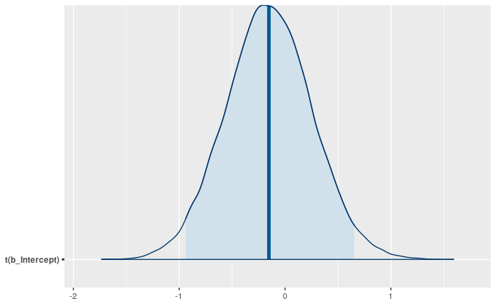

```r
mcmc_plot(m_scores, pars = c("b_Intercept"), exact_match = TRUE, type = "areas", prob = .95, transformations = function(x) {exp(x) + improvement_min})
```

The intercept term in this model represents the estimated improvement in test score from the Default block to the Fact block, across condition orders. The plot above shows the estimated distribution of the improvement coefficient. It is quite clear that there is no improvement. A Savage-Dickey density ratio test shows that there is indeed some evidence against a change in test score between conditions:

```r
prior_density_at_zero <- dcauchy(0, 0, 1)

m_scores_posterior_samples <- exp(posterior_samples(m_scores, pars = "b_Intercept")$b_Intercept) + improvement_min
m_scores_posterior_density_at_zero <- density_ratio(m_scores_posterior_samples, point = 0)

bf_scores <- prior_density_at_zero / m_scores_posterior_density_at_zero
1/bf_scores
```

```
[1] 2.864166
```

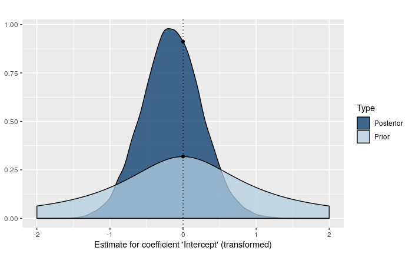

```r
xval <- seq(-2, 2, by = 0.01)
plot_prior <- dcauchy(xval, location = 0, scale = 1)
plot_posterior <- density_ratio(x = m_scores_posterior_samples, y = NULL, point = xval) # Returns the density of the posterior at each point in x
m_scores_density <- tibble(xval = xval, Prior = plot_prior, Posterior = plot_posterior)

gather(m_scores_density, -xval, key = "Type", value = "density") %>%
  mutate(density = ifelse(density < 0, 0, density)) %>%
  ggplot(aes(x = xval, y = density, fill = Type)) +
  geom_area(position = "identity", colour = "black", alpha = 0.75) +
  geom_vline(xintercept = 0, lty = 3) +
  annotate("point", x = c(0, 0), y = c(prior_density_at_zero, m_scores_posterior_density_at_zero)) +
  labs(x = "Estimate for coefficient 'Intercept' (transformed)", y = NULL, title = "") +
  scale_fill_manual(values = c("#03396c", "#b3cde0"))
```

# Test accuracy on unseen items

Participants could rehearse up to 30 items during each learning session. Regardless of the number of items they actually saw, they were tested on all 30. We would not expect participants to answer unseen items correctly, unless they just happen to know the location of a city.

Out of a total of 1806 unstudied items across all participants and blocks, 7 were answered correctly. These responses are shown below. All of them are large cities that could reasonably be guessed based on prior knowledge.

```r
cities <- read_csv(file.path("..", "stimuli", "setC.csv"), col_types = cols(
  id = col_factor(),
  image = col_character(),
  text = col_logical(),
  answer = col_character()
)) %>%
  select(fact_id = id, answer)

filter(test, !studied, correct) %>%
  left_join(cities, by = "fact_id")
```

| subject | block | condition | fact_id | correct | studied | answer |
| --- | --- | --- | --- | --- | --- | --- |
| rbhcsj79fk8t7pe | 1 | default | 34 | TRUE | FALSE | miami |
| cfl6vmvanv12fb5 | 1 | default | 41 | TRUE | FALSE | phoenix |
| 3n5rwen2gntwwfh | 1 | fact | 49 | TRUE | FALSE | seattle |
| uehekm8xdnul52q | 1 | default | 49 | TRUE | FALSE | seattle |
| 3mae1wznq7d279u | 1 | fact | 17 | TRUE | FALSE | detroit |
| 3mae1wznq7d279u | 1 | fact | 16 | TRUE | FALSE | denver |
| ojqdd85kg74abvw | 2 | default | 13 | TRUE | FALSE | dallas |

# Test accuracy on all items

Rather than only looking at test responses on facts that were studied during the learning session, we can evaluate the evidence for an effect of condition on test accuracy on *all* 30 items in the stimulus set. Based on the observation that unseen items are almost universally answered incorrectly, we would expect to find a similar but much diluted effect of condition.

The plot below shows test accuracy on all 30 items. As expected, the distributions look more or less the same but shifted downward.

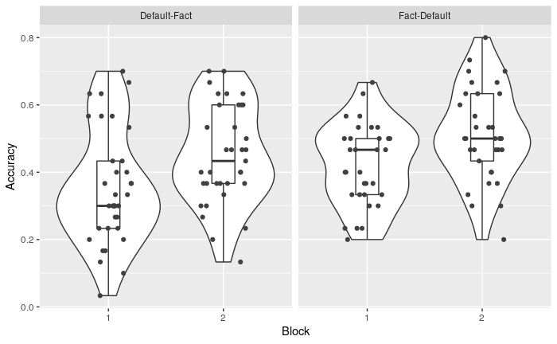

```r
test$studied <- ifelse(is.na(test$studied), FALSE, test$studied)

test_acc <- test %>%
  group_by(subject, block, condition) %>%
  summarise(p_corr = mean(correct)) %>%
    mutate(condition_order = case_when(
    block == 1 && condition == "default" ~ "Default-Fact",
    block == 2 && condition == "fact" ~ "Default-Fact",
    block == 1 && condition == "fact" ~ "Fact-Default",
    block == 2 && condition == "default" ~ "Fact-Default"
  ))

ggplot(test_acc, aes(x = block, y = p_corr)) +
  facet_grid(~ condition_order) +
  geom_violin() +
  geom_boxplot(width = 0.2) +
  geom_jitter(width = 0.2, height = 0, colour = "grey25") +
  labs(x = "Block", y = "Accuracy")
```

Fit the same model as before, but now including all items (note that this is obviously an inappropriate model, since the largest source of variance—whether or not the item was studied—is not included):

```r
contrasts(test$condition) <- c(-0.5, 0.5)
contrasts(test$condition)
```

```
        [,1]
default -0.5
fact     0.5
```

```r
contrasts(test$block) <- c(-0.5, 0.5)
contrasts(test$block)
```

```
  [,1]
1 -0.5
2  0.5
```

```r
m1_all <- brm(
  correct ~ condition + block + (1 | subject) + (1 | fact_id),
  family = bernoulli,
  data = test,
  prior = prior_m1,
  chains = 4,
  iter = 10000,
  save_all_pars = TRUE,
  sample_prior = TRUE,
  future = TRUE,
  seed = 0,
  file = "model_fits/m1_all"
)
```

```
No divergences to plot.
```

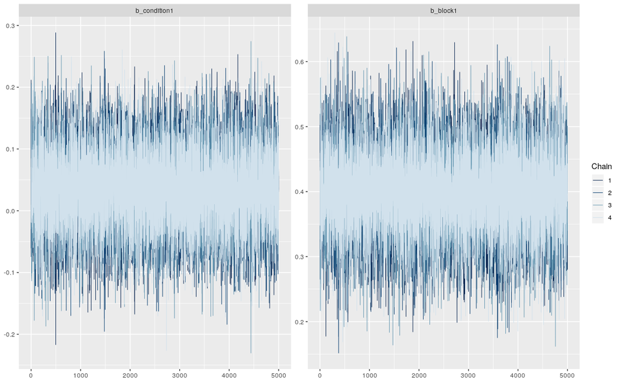

```r
mcmc_plot(m1_all, pars = c("condition", "block"), type = "trace")
```